# Post Overview.

# Demonstrate how perform a Paired-Sample T-Test using SPSS.

#### Steps

1. Review case and organize variables, and set-up hypothesis.
2. Set up data in SPSS.
3. Confirm data does not violate assumptions.
4. Carry out Paired-Sample T-Test.
5. Interpret Results.
6. Calculate Effect Size.

### Review case and organize variables, and set-up hypothesis

- **Project:** A supplement company wants to test a new formulation of their pre-workout beverage to determine if it improves the running performance. They have a standard pre-workout formulation with electrolytes and caffeine, but want to test a new mixture that contains carbohydrates.
- **Sample size:** A total of 20 participants were recruited to perform two trials in which they had to run as far as possible for 1 hour on a treadmill. In one trial they drank the pre-workout beverage only and the distance ran was measured. In the second trial, they drank the pre-workout with carbohydrates, and the distance ran was also measured..
- **Independent Variable:** The pre-workout beverage type.
- **Dependent Variable:** The distance ran.
- **Goal:** Determine if the new formulation leads to difference in performance compared to the standard pre-workout drink.
- **The Null hypothesis** \(H_{0}: \mu_{diff} = 0 \): The mean difference between the paired values is zero.
- **The Alternative hypothesis** \(H_{A}: \mu_{diff} \neq 0 \): The mean difference between the paired values is not zero.
- **The Level of Significance** \(\alpha = 0.05\).

### Set up data in SPSS

**SPSS Variable View**

- Either import or manually input data for the variables of interest.

**SPSS Data View**

- There are 20 total instances of data, with two columns representing the distance ran after having either the standard pre-workout or the pre-workout drink with carbohydrates.

**Add a new feature to the data, the difference between the paired values.**

- In a paired-samples t-test, we the assumption of normality and the presence of no outliers on the differences between the paired-values, not the values of the paired groups themselves. So we must add this feature to the data frame.
- **Steps:** `Transform > Compute Variable > In Compute Variable dialogue box > Type "Difference" in Target Variable text field > In Numeric Expression text box Preworkout_carbs - preworkout > OK button`. These steps will add a new column in the table. We can then test the assumptions for a Paired-Sample T-Test.

[figure not shown]

```python
# Variable view
img = os.path.join(path, 'static/images/paired_sample/spss1.png')
Image(filename=img,  width = 900)
```

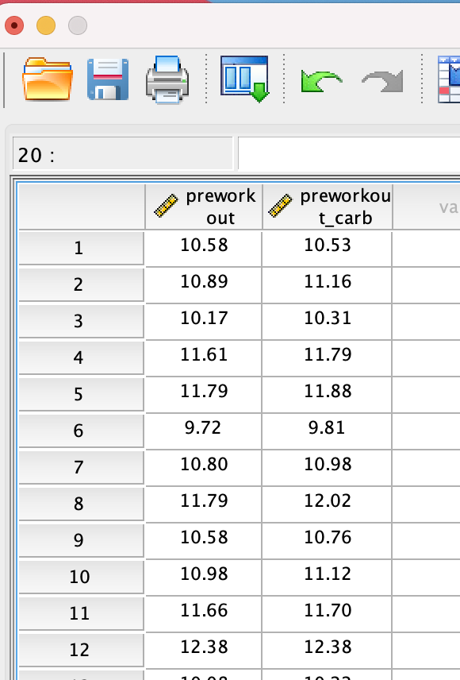

```python
# Data view
img = os.path.join(path, 'static/images/paired_sample/spss2.png')
Image(filename=img,  width = 300)
```

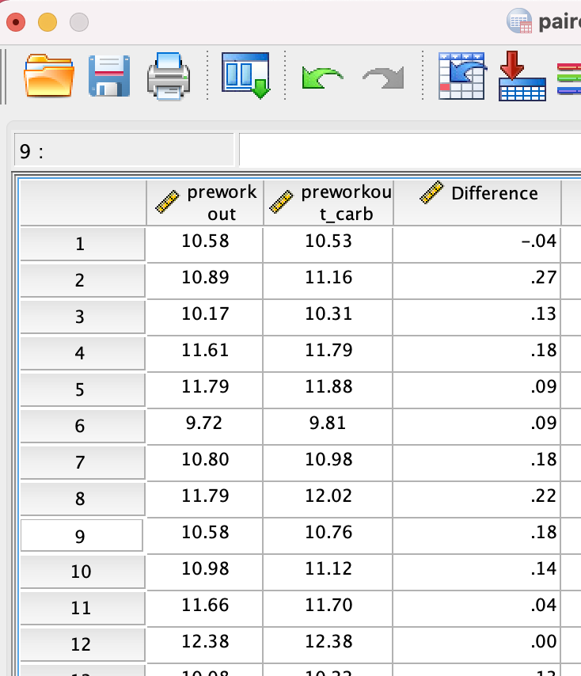

```python
# New Data view
img = os.path.join(path, 'static/images/paired_sample/spss3.png')
Image(filename=img,  width = 350)
```

### Confirm data does not violate assumptions

**Why confirm assumptions?**

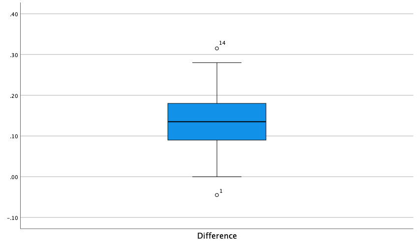

```python
# assumption 4
img = os.path.join(path, 'static/images/paired_sample/spss4.png')
Image(filename=img,  width = 700)
```

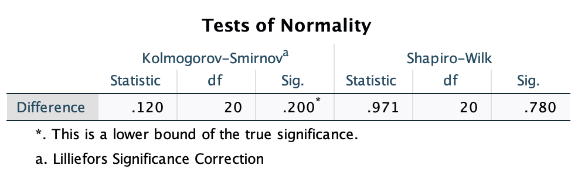

```python
# normality
img = os.path.join(path, 'static/images/paired_sample/spss5.png')
Image(filename=img,  width = 800)
```

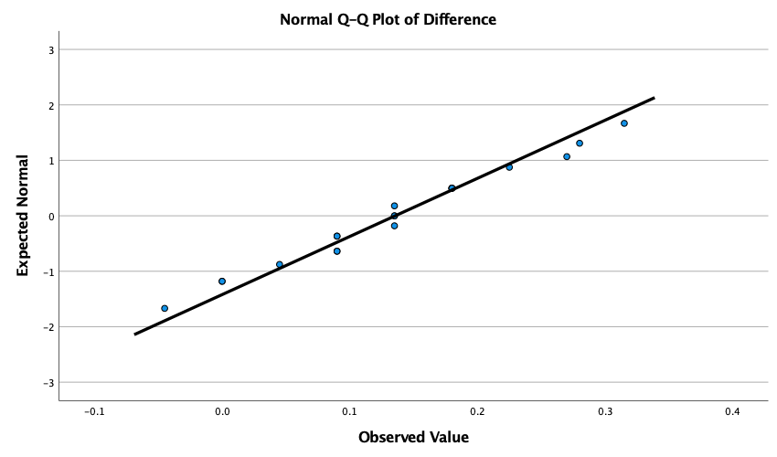

```python
# normality
img = os.path.join(path, 'static/images/paired_sample/spss6.png')
Image(filename=img,  width = 800)
```

### Carry out Paired-Sample T-Test.

**Procedure**

1. `Analyze > Compare Means > Paired-Sample T Test`
2. **Paired-Samples T Test dialogue box**: `Move preworkout variables to Paired Variables box > click swap button to make sure we subtract preworkout with carbs to preworkout only > Click Continue to return to Paired-Sample T Test dialogue box > Click OK button to generate output`

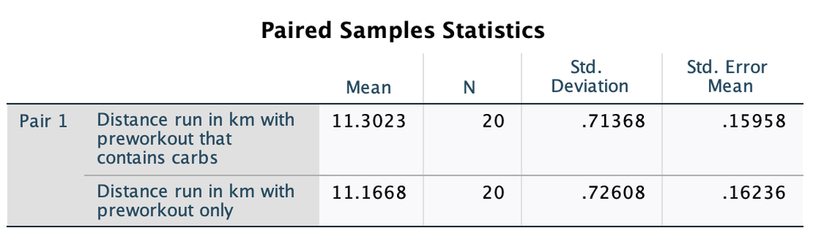

```python
img = os.path.join(path, 'static/images/paired_sample/spss7.png')
Image(filename=img, width=800)
```

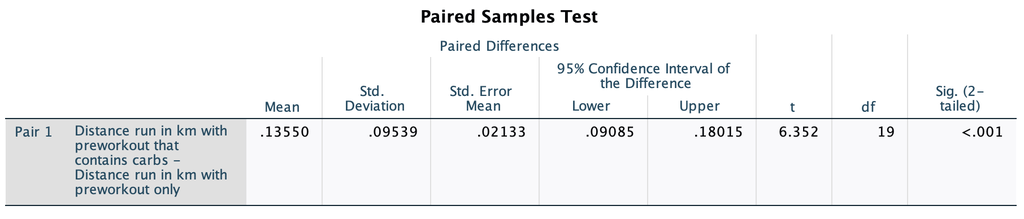

```python
img = os.path.join(path, 'static/images/paired_sample/spss8.png')
Image(filename=img, width=850)
```

**Paired sample statistics Preworkout with carb vs Preworkout.**

- The mean difference for both groups is 11.3 and 11.2 respectively.
- The standard deviation is 0.71 and 0.73 respectively.
- Data are mean ± standard deviation, unless otherwise stated. Participants ran further when imbibing the carbohydrate-preworkout drink (11.302 ± 0.714 km) as opposed to the preworkout-only drink (11.167 ± 0.726 km).

**Paired Samples Test**

- The mean difference is 0.1355 with a confidence interval of the difference between 0.09 and 0.18.
- The p-value for the difference is less than 0.001.
- The carbohydrate-preworkout drink elicited an increase of 0.136 (95% CI, 0.091 to 0.180) km in the distance run in one hour compared to a preworkout-only drink.

### Interpret Results.

**Paired Sample Test**

- The carbohydrate-preworkout drink elicited a statistically significant increase in distance run in one hours compared to a preworkout-only drink, \(t(19) = 6.352, p < .0005\).
- **Recommendation:** Recommend the new preworkout formulation as a performance enhancement supplement for runners.

### Calculate the effect size using Cohen's d.

**Effect size**

  | Effect Size | Strength |
  | --- | --- |
  | 0.2 | Small |
  | 0.5 | Medium |
  | 0.8 | Large |

- The carbohydrate-preworkout drink elicited a statistically significant mean increase in distance run in one hours compared to a preworkout-only drink, \(t(19) = 6.352, p < .0005, d = 1.42\).

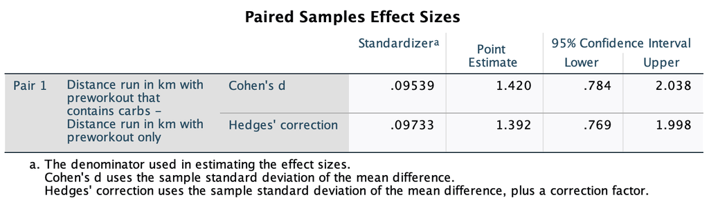

```python
img = os.path.join(path, 'static/images/paired_sample/spss9.png')
Image(filename=img, width=850)
```

# Graphical Overview of a Paired-Sample T-Test.

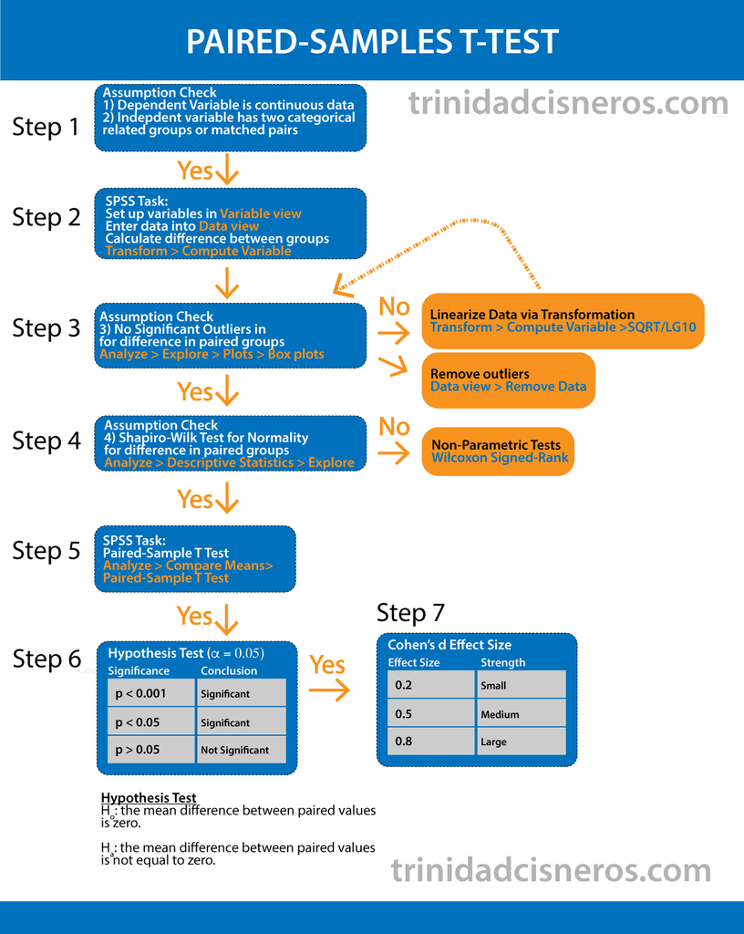

```python
img = os.path.join(path, 'static/images/paired_sample/spss10.png')
Image(filename=img, width=850)
```